# HomeWork 2

Soonchan Kwon

2022-05-01

# 1 회귀분석 실습파일

프로야구에는 수 많은 타자들의 개인 기록들이 있다.  
선수들이 그 기록들을 좋게 유지하려는 이유는 그들이 받게되는 연봉을 높이기 위해서다.  
따라서 야구를 즐겨보는 입장으로서 어떤 기록이 연봉 인상에 유의미한 영향을 미치는지 알아보고자 한다.

## 1.1 데이터 수집

```r
#데이터는 1986년 MLB 타자 데이터셋을 이용하였다.
library(ISLR)
names(Hitters)
```

```
##  [1] "AtBat"     "Hits"      "HmRun"     "Runs"      "RBI"       "Walks"
##  [7] "Years"     "CAtBat"    "CHits"     "CHmRun"    "CRuns"     "CRBI"
## [13] "CWalks"    "League"    "Division"  "PutOuts"   "Assists"   "Errors"
## [19] "Salary"    "NewLeague"
```

변수 설명  
[AtBat] - Number of times at bat in 1986  
[Hits] - Number of hits in 1986  
[HmRun] - Number of home runs in 1986  
[Runs] - Number of runs in 1986  
[RBI] - Number of runs batted in in 1986  
[Walks] - Number of walks in 1986  
[Years] - Number of years in the major leagues  
[CAtBat] - Number of times at bat during his career  
[CHits] - Number of hits during his career  
[CHmRun] - Number of home runs during his career  
[CRuns] - Number of runs during his career  
[CRBI] - Number of runs batted in during his career  
[CWalks] - Number of walks during his career  
[League] - A factor with levels A and N indicating player’s league at the end of 1986  
[Division] - A factor with levels E and W indicating player’s division at the end of 1986  
[PutOuts] - Number of put outs in 1986  
[Assists] - Number of assists in 1986  
[Errors] - Number of errors in 1986  
[Salary] - 1987 annual salary on opening day in thousands of dollars  
[NewLeague] - A factor with levels A and N indicating player’s league at the beginning of 1987

주요 변수 해석

- [타수 (AtBat)] 타자가 정규로 타격을 완료한 횟수
- [안타 (Hits)] 타자가 안전하게 베이스에 나아갈 수 있도록 친 타구
- [홈런 (HmRun)] 인플레이 중 타자가 홈으로 들어와 득점한 상황
- [득점 (Runs)] 주자가 본루를 밟음으로써 기록되는 공격측의 점수
- [타점 (RBI)] 타구를 쳐 주자가 득점에 성공했을 경우 주어지는 점수
- [볼넷 (Walks)] 타자가 4개의 볼을 골라 1루로 나가는 것
- [연차 (Years)] 데뷔 햇수
- [리그 (League)] 팀이 속해있는 리그
- [자살 (PutOuts)] 야수가 직접 아웃시킨 경우
- [보살 (Assists)] 야수가 PutOut할 수 있도록 도와준 경우
- [실책 (Errors)] 야수의 실수로 주자가 진루한 경우
- [연봉 (Salary)] 일 년 동안에 받는 봉급의 총액

### 1.1.1 데이터 전처리 1

데이터 셋의 결측치가 있는지 확인하였고  
결측치를 제거하는 과정을 행함

```r
#결측치 합산
sum(is.na(Hitters))
```

```
## [1] 59
```

```r
#결측치 제거
Hitters<- na.omit(Hitters)
```

### 1.1.2 데이터 전처리 2

변수의 데이터 타입을 확인하였고  
존재하는 범주형 변수를 적절하게 수치형으로 변형

```r
#데이터 셋의 타입을 확인
sapply(Hitters, FUN = "class")
```

```
##     AtBat      Hits     HmRun      Runs       RBI     Walks     Years    CAtBat
## "integer" "integer" "integer" "integer" "integer" "integer" "integer" "integer"
##     CHits    CHmRun     CRuns      CRBI    CWalks    League  Division   PutOuts
## "integer" "integer" "integer" "integer" "integer"  "factor"  "factor" "integer"
##   Assists    Errors    Salary NewLeague
## "integer" "integer" "numeric"  "factor"
```

```r
#범주형 변수를 더미 변수처리
#install.packages("https://cran.r-project.org/src/contrib/Archive/dummies/dummies_1.5.6.tar.gz", repos = NULL, type="source")
library(dummies)
#League 변수 처리
H <- dummy.data.frame(Hitters, names=c("League"))
#Division 변수 처리
H <- dummy.data.frame(H, names=c("Division"))
#NewLeague 변수 처리
H <- dummy.data.frame(H, names=c("NewLeague"))
#잘 변형 되었는지 확인
head(H, 10)
```

```
##                   AtBat Hits HmRun Runs RBI Walks Years CAtBat CHits CHmRun
## -Alan Ashby         315   81     7   24  38    39    14   3449   835     69
## -Alvin Davis        479  130    18   66  72    76     3   1624   457     63
## -Andre Dawson       496  141    20   65  78    37    11   5628  1575    225
## -Andres Galarraga   321   87    10   39  42    30     2    396   101     12
## -Alfredo Griffin    594  169     4   74  51    35    11   4408  1133     19
## -Al Newman          185   37     1   23   8    21     2    214    42      1
## -Argenis Salazar    298   73     0   24  24     7     3    509   108      0
## -Andres Thomas      323   81     6   26  32     8     2    341    86      6
## -Andre Thornton     401   92    17   49  66    65    13   5206  1332    253
## -Alan Trammell      574  159    21  107  75    59    10   4631  1300     90
##                   CRuns CRBI CWalks LeagueA LeagueN DivisionE DivisionW PutOuts
## -Alan Ashby         321  414    375       0       1         0         1     632
## -Alvin Davis        224  266    263       1       0         0         1     880
## -Andre Dawson       828  838    354       0       1         1         0     200
## -Andres Galarraga    48   46     33       0       1         1         0     805
## -Alfredo Griffin    501  336    194       1       0         0         1     282
## -Al Newman           30    9     24       0       1         1         0      76
## -Argenis Salazar     41   37     12       1       0         0         1     121
## -Andres Thomas       32   34      8       0       1         0         1     143
## -Andre Thornton     784  890    866       1       0         1         0       0
## -Alan Trammell      702  504    488       1       0         1         0     238
##                   Assists Errors   Salary NewLeagueA NewLeagueN
## -Alan Ashby            43     10  475.000          0          1
## -Alvin Davis           82     14  480.000          1          0
## -Andre Dawson          11      3  500.000          0          1
## -Andres Galarraga      40      4   91.500          0          1
## -Alfredo Griffin      421     25  750.000          1          0
## -Al Newman            127      7   70.000          1          0
## -Argenis Salazar      283      9  100.000          1          0
## -Andres Thomas        290     19   75.000          0          1
## -Andre Thornton         0      0 1100.000          1          0
## -Alan Trammell        445     22  517.143          1          0
```

## 1.2 탐색적 데이터 분석

각 변수의 특징을 시각화를 통해 살펴봄

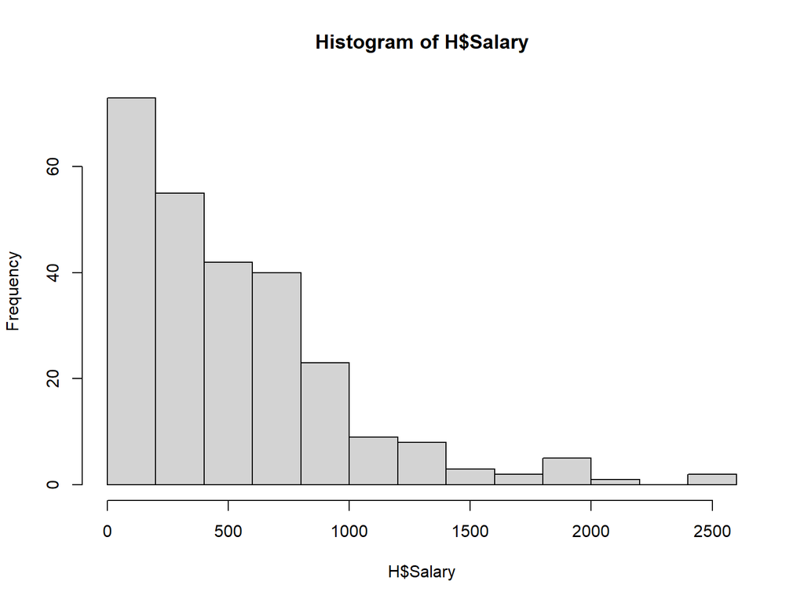

```r
#연봉 데이터를 히스토그램으로 표현
hist(H$Salary)
```

히스토그램 분포를 통해 고액의 연봉을 받는 선수는 매우 소수에 해당되고  
대체적으로 0 ~ 500,000$ 근처 연봉을 받는 빈도가 가장 높은 것을 알 수 있음

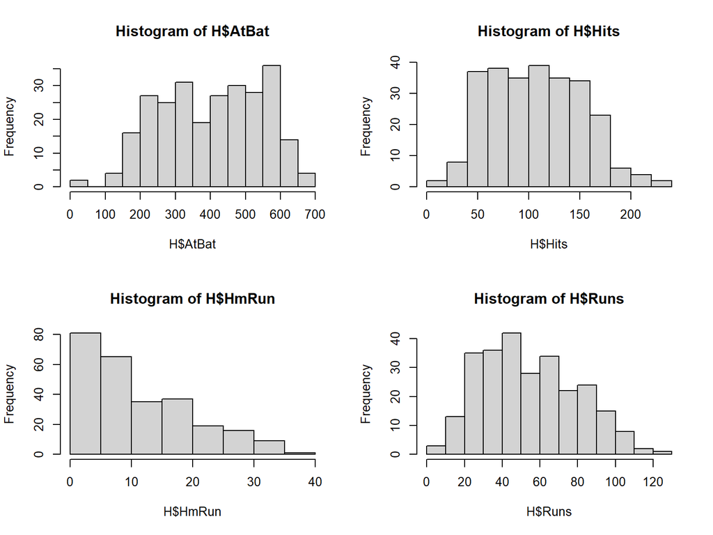

```r
#나머지 변수들의 데이터를 히스토그램으로 표현
library("ggplot2")
par(mfrow=c(2,2))
hist(H$AtBat)
hist(H$Hits)
hist(H$HmRun)
hist(H$Runs)
```

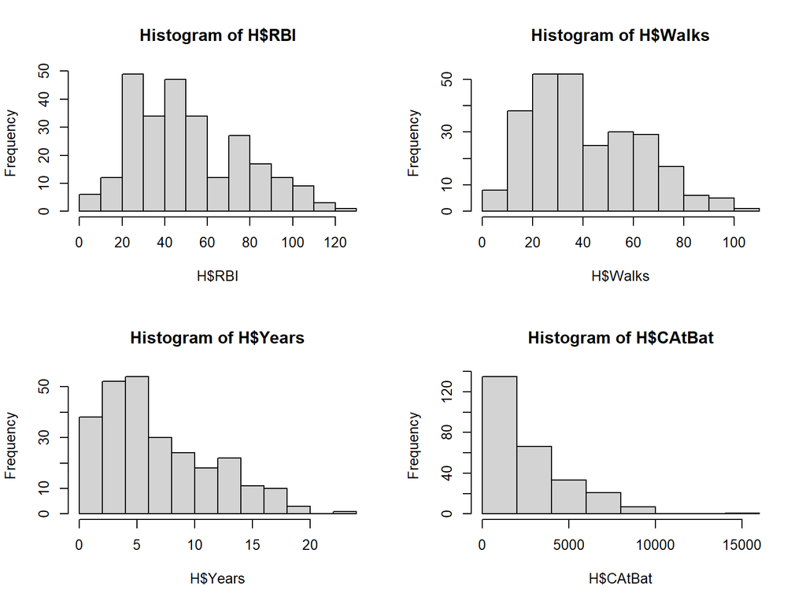

```r
par(mfrow=c(2,2))
hist(H$RBI)
hist(H$Walks)
hist(H$Years)
hist(H$CAtBat)
```

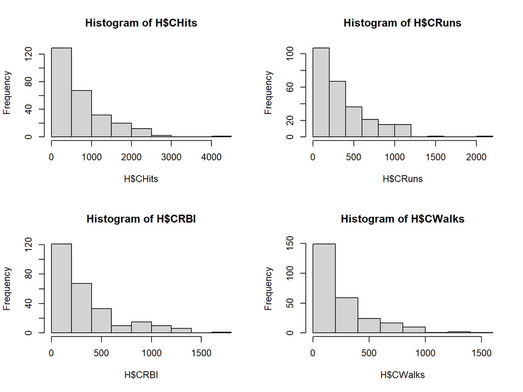

```r
par(mfrow=c(2,2))
hist(H$CHits)
hist(H$CRuns)
hist(H$CRBI)
hist(H$CWalks)
```

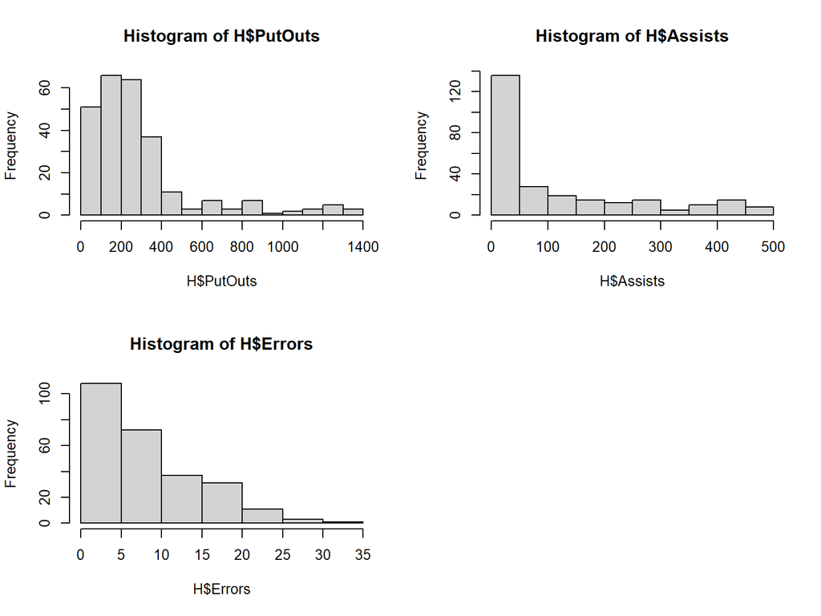

```r
par(mfrow=c(2,2))
hist(H$PutOuts)
hist(H$Assists)
hist(H$Errors)
```

각 변수들도 데이터가 고르게 분포하는 것은 아님을 확인  
또한, 변수들간의 단위가 각각 다르다는 사실을 발견

따라서 데이터의 스케일링 과정이 필요

### 1.2.1 데이터 전처리3

scaling 처리

```r
# caret 패키지를 활용
# install.packages("caret")
library(caret)
HC <- caret::preProcess(H, method = c("center", "scale"))

#확인
HC
```

```
## Created from 263 samples and 23 variables
##
## Pre-processing:
##   - centered (23)
##   - ignored (0)
##   - scaled (23)
```

```r
# scaling 진행
HCD <- predict(HC, H)

#알맞게 scaling 되었는지 데이터를 확인
summary(HCD)
```

```
##      AtBat               Hits             HmRun              Runs
##  Min.   :-2.61116   Min.   :-2.3674   Min.   :-1.3269   Min.   :-2.1435
##  1st Qu.:-0.82238   1st Qu.:-0.8051   1st Qu.:-0.7559   1st Qu.:-0.8318
##  Median : 0.06352   Median :-0.1070   Median :-0.2992   Median :-0.1075
##  Mean   : 0.00000   Mean   : 0.0000   Mean   : 0.0000   Mean   : 0.0000
##  3rd Qu.: 0.83063   3rd Qu.: 0.7462   3rd Qu.: 0.7286   3rd Qu.: 0.7148
##  Max.   : 1.92358   Max.   : 2.8847   Max.   : 3.2408   Max.   : 2.9466
##       RBI              Walks             Years             CAtBat
##  Min.   :-1.9892   Min.   :-1.8931   Min.   :-1.3167   Min.   :-1.1539
##  1st Qu.:-0.8302   1st Qu.:-0.8341   1st Qu.:-0.6909   1st Qu.:-0.7938
##  Median :-0.1733   Median :-0.1894   Median :-0.2737   Median :-0.3177
##  Mean   : 0.0000   Mean   : 0.0000   Mean   : 0.0000   Mean   : 0.0000
##  3rd Qu.: 0.7539   3rd Qu.: 0.7315   3rd Qu.: 0.5608   3rd Qu.: 0.5392
##  Max.   : 2.6857   Max.   : 2.9416   Max.   : 3.4813   Max.   : 4.9836
##      CHits             CHmRun            CRuns              CRBI
##  Min.   :-1.1080   Min.   :-0.8424   Min.   :-1.0846   Min.   :-1.0125
##  1st Qu.:-0.7871   1st Qu.:-0.6599   1st Qu.:-0.7721   1st Qu.:-0.7280
##  Median :-0.3181   Median :-0.3557   Median :-0.3358   Median :-0.3105
##  Mean   : 0.0000   Mean   : 0.0000   Mean   : 0.0000   Mean   : 0.0000
##  3rd Qu.: 0.5119   3rd Qu.: 0.2830   3rd Qu.: 0.4115   3rd Qu.: 0.2909
##  Max.   : 5.4517   Max.   : 5.8245   Max.   : 5.4462   Max.   : 4.1086
##      CWalks           LeagueA           LeagueN          DivisionE
##  Min.   :-0.9819   Min.   :-1.0567   Min.   :-0.9427   Min.   :-0.9793
##  1st Qu.:-0.7168   1st Qu.:-1.0567   1st Qu.:-0.9427   1st Qu.:-0.9793
##  Median :-0.3267   Median : 0.9427   Median :-0.9427   Median :-0.9793
##  Mean   : 0.0000   Mean   : 0.0000   Mean   : 0.0000   Mean   : 0.0000
##  3rd Qu.: 0.2584   3rd Qu.: 0.9427   3rd Qu.: 1.0567   3rd Qu.: 1.0173
##  Max.   : 4.9449   Max.   : 0.9427   Max.   : 1.0567   Max.   : 1.0173
##    DivisionW          PutOuts           Assists            Errors
##  Min.   :-1.0173   Min.   :-1.0385   Min.   :-0.8186   Min.   :-1.3007
##  1st Qu.:-1.0173   1st Qu.:-0.6330   1st Qu.:-0.7634   1st Qu.:-0.8466
##  Median : 0.9793   Median :-0.2383   Median :-0.5084   Median :-0.2411
##  Mean   : 0.0000   Mean   : 0.0000   Mean   : 0.0000   Mean   : 0.0000
##  3rd Qu.: 0.9793   3rd Qu.: 0.1136   3rd Qu.: 0.5048   3rd Qu.: 0.6670
##  Max.   : 0.9793   Max.   : 3.8805   Max.   : 2.5726   Max.   : 3.5430
##      Salary          NewLeagueA        NewLeagueN
##  Min.   :-1.0384   Min.   :-1.0730   Min.   :-0.9284
##  1st Qu.:-0.7668   1st Qu.:-1.0730   1st Qu.:-0.9284
##  Median :-0.2459   Median : 0.9284   Median :-0.9284
##  Mean   : 0.0000   Mean   : 0.0000   Mean   : 0.0000
##  3rd Qu.: 0.4745   3rd Qu.: 0.9284   3rd Qu.: 1.0730
##  Max.   : 4.2651   Max.   : 0.9284   Max.   : 1.0730
```

이제 모델을 구축할 준비를 모두 완료함  
…………………………………………………………………..

위와 같이 스케일링 처리 후 모형을 구축하여 회귀분석을 진행하고 여러 과정을 거침  
그러나 accuracy 함수를 통해 성능평가를 하는 중 MAPE값이 비정상적으로 크게 발견되어 진행하고 있던 모형을 구축하고 해석하는 과정을 뒤로하고  
다시 전처리 과정으로 돌아와 잘못 설계한 부분을 점검

점검 결과 변수들 간의 단위 차이가 Salary 변수에서 특히 유의미하게 벌어지므로  
scaling 과정을 취소하고 Salary 변수에 log를 취해 모형을 구축하기로 결정  
또한, R언어 자체에 범주형 변수를 분석에 적합하게 처리해 주는 점을 생각해 결측치만 삭제하고 진행

## 1.3 학습모델 구축

```r
#결측치 값 제거
Hitters <- na.omit(Hitters)

#모든변수를 포함한 모형 구축
modeln = lm(log(Salary) ~., data = Hitters)
summary(modeln)
```

```
##
## Call:
## lm(formula = log(Salary) ~ ., data = Hitters)
##
## Residuals:
##      Min       1Q   Median       3Q      Max
## -2.22870 -0.45350  0.09424  0.40474  2.77223
##
## Coefficients:
##               Estimate Std. Error t value Pr(>|t|)
## (Intercept)  4.618e+00  1.765e-01  26.171  < 2e-16 ***
## AtBat       -2.984e-03  1.232e-03  -2.421  0.01620 *
## Hits         1.308e-02  4.622e-03   2.831  0.00503 **
## HmRun        1.179e-02  1.205e-02   0.978  0.32889
## Runs        -1.419e-03  5.794e-03  -0.245  0.80670
## RBI         -1.675e-03  5.056e-03  -0.331  0.74063
## Walks        1.096e-02  3.554e-03   3.082  0.00229 **
## Years        5.696e-02  2.413e-02   2.361  0.01902 *
## CAtBat       1.283e-04  2.629e-04   0.488  0.62596
## CHits       -4.414e-04  1.311e-03  -0.337  0.73670
## CHmRun      -7.809e-05  3.144e-03  -0.025  0.98020
## CRuns        1.513e-03  1.459e-03   1.037  0.30072
## CRBI         1.312e-04  1.346e-03   0.097  0.92246
## CWalks      -1.466e-03  6.377e-04  -2.298  0.02239 *
## LeagueN      2.825e-01  1.541e-01   1.833  0.06797 .
## DivisionW   -1.656e-01  7.847e-02  -2.111  0.03580 *
## PutOuts      3.389e-04  1.505e-04   2.251  0.02526 *
## Assists      6.214e-04  4.300e-04   1.445  0.14970
## Errors      -1.197e-02  8.537e-03  -1.402  0.16225
## NewLeagueN  -1.742e-01  1.536e-01  -1.134  0.25788
## ---
## Signif. codes:  0 '***' 0.001 '**' 0.01 '*' 0.05 '.' 0.1 ' ' 1
##
## Residual standard error: 0.6135 on 243 degrees of freedom
## Multiple R-squared:  0.5586, Adjusted R-squared:  0.524
## F-statistic: 16.18 on 19 and 243 DF,  p-value: < 2.2e-16
```

변수 선택법 중 p-value값에 의해 변수를 제거하는 방법을 채택  
p-value 값에 의하여 CHmRun, CRBI, Runs, RBI, CHits 제거

```r
modeln = lm(log(Salary) ~ AtBat + Hits + HmRun + Walks + Years + CAtBat + CRuns + CWalks
            + League + Division + PutOuts + Assists + Errors + NewLeague, data = Hitters)
summary(modeln)
```

```
##
## Call:
## lm(formula = log(Salary) ~ AtBat + Hits + HmRun + Walks + Years +
##     CAtBat + CRuns + CWalks + League + Division + PutOuts + Assists +
##     Errors + NewLeague, data = Hitters)
##
## Residuals:
##     Min      1Q  Median      3Q     Max
## -2.1926 -0.4629  0.1024  0.4152  2.7709
##
## Coefficients:
##               Estimate Std. Error t value Pr(>|t|)
## (Intercept)  4.617e+00  1.743e-01  26.496  < 2e-16 ***
## AtBat       -2.808e-03  1.100e-03  -2.553 0.011281 *
## Hits         1.149e-02  3.230e-03   3.556 0.000451 ***
## HmRun        9.348e-03  5.992e-03   1.560 0.120039
## Walks        1.035e-02  3.109e-03   3.328 0.001008 **
## Years        5.843e-02  2.350e-02   2.487 0.013549 *
## CAtBat       4.255e-05  1.275e-04   0.334 0.738945
## CRuns        1.202e-03  8.156e-04   1.474 0.141639
## CWalks      -1.296e-03  5.182e-04  -2.502 0.013001 *
## LeagueN      2.871e-01  1.520e-01   1.888 0.060147 .
## DivisionW   -1.626e-01  7.674e-02  -2.119 0.035123 *
## PutOuts      3.324e-04  1.466e-04   2.267 0.024266 *
## Assists      6.456e-04  4.171e-04   1.548 0.122986
## Errors      -1.259e-02  8.374e-03  -1.504 0.133865
## NewLeagueN  -1.809e-01  1.509e-01  -1.199 0.231528
## ---
## Signif. codes:  0 '***' 0.001 '**' 0.01 '*' 0.05 '.' 0.1 ' ' 1
##
## Residual standard error: 0.6077 on 248 degrees of freedom
## Multiple R-squared:  0.5579, Adjusted R-squared:  0.533
## F-statistic: 22.36 on 14 and 248 DF,  p-value: < 2.2e-16
```

p-value 값에 의하여 CAtBat 변수 제거

```r
modeln = lm(log(Salary) ~ AtBat + Hits + HmRun + Walks + Years + CRuns + CWalks
            + League + Division + PutOuts + Assists + Errors + NewLeague, data = Hitters)
summary(modeln)
```

```
##
## Call:
## lm(formula = log(Salary) ~ AtBat + Hits + HmRun + Walks + Years +
##     CRuns + CWalks + League + Division + PutOuts + Assists +
##     Errors + NewLeague, data = Hitters)
##
## Residuals:
##      Min       1Q   Median       3Q      Max
## -2.19481 -0.46050  0.09743  0.41342  2.76673
##
## Coefficients:
##               Estimate Std. Error t value Pr(>|t|)
## (Intercept)  4.6006092  0.1667431  27.591  < 2e-16 ***
## AtBat       -0.0027672  0.0010911  -2.536 0.011823 *
## Hits         0.0114408  0.0032215   3.551 0.000458 ***
## HmRun        0.0092905  0.0059792   1.554 0.121500
## Walks        0.0101118  0.0030232   3.345 0.000950 ***
## Years        0.0633225  0.0183273   3.455 0.000647 ***
## CRuns        0.0014335  0.0004301   3.333 0.000989 ***
## CWalks      -0.0012975  0.0005173  -2.508 0.012765 *
## LeagueN      0.2888606  0.1516832   1.904 0.058015 .
## DivisionW   -0.1584000  0.0755762  -2.096 0.037101 *
## PutOuts      0.0003375  0.0001456   2.318 0.021241 *
## Assists      0.0006628  0.0004132   1.604 0.109913
## Errors      -0.0124519  0.0083484  -1.492 0.137085
## NewLeagueN  -0.1771682  0.1501705  -1.180 0.239214
## ---
## Signif. codes:  0 '***' 0.001 '**' 0.01 '*' 0.05 '.' 0.1 ' ' 1
##
## Residual standard error: 0.6066 on 249 degrees of freedom
## Multiple R-squared:  0.5577, Adjusted R-squared:  0.5346
## F-statistic: 24.15 on 13 and 249 DF,  p-value: < 2.2e-16
```

p-value 값에 의하여 NewLeague, Errors, HmRun 변수 제거

```r
modeln = lm(log(Salary) ~ AtBat + Hits + Walks + Years + CRuns + CWalks
            + League + Division + PutOuts + Assists , data = Hitters)
summary(modeln)
```

```
##
## Call:
## lm(formula = log(Salary) ~ AtBat + Hits + Walks + Years + CRuns +
##     CWalks + League + Division + PutOuts + Assists, data = Hitters)
##
## Residuals:
##      Min       1Q   Median       3Q      Max
## -2.23028 -0.45300  0.08331  0.41116  2.86924
##
## Coefficients:
##               Estimate Std. Error t value Pr(>|t|)
## (Intercept)  4.550e+00  1.651e-01  27.555  < 2e-16 ***
## AtBat       -2.564e-03  1.048e-03  -2.446 0.015110 *
## Hits         1.172e-02  3.216e-03   3.645 0.000325 ***
## Walks        1.015e-02  3.032e-03   3.347 0.000943 ***
## Years        6.389e-02  1.839e-02   3.474 0.000603 ***
## CRuns        1.365e-03  4.313e-04   3.164 0.001747 **
## CWalks      -1.159e-03  5.162e-04  -2.246 0.025585 *
## LeagueN      1.068e-01  7.736e-02   1.380 0.168751
## DivisionW   -1.599e-01  7.598e-02  -2.105 0.036312 *
## PutOuts      3.208e-04  1.454e-04   2.206 0.028308 *
## Assists      9.209e-05  2.904e-04   0.317 0.751385
## ---
## Signif. codes:  0 '***' 0.001 '**' 0.01 '*' 0.05 '.' 0.1 ' ' 1
##
## Residual standard error: 0.6098 on 252 degrees of freedom
## Multiple R-squared:  0.5476, Adjusted R-squared:  0.5296
## F-statistic:  30.5 on 10 and 252 DF,  p-value: < 2.2e-16
```

p-value 값에 의하여 Assist, League 변수 제거

```r
modeln = lm(log(Salary) ~ AtBat + Hits + Walks + Years + CRuns + CWalks
             + Division + PutOuts  , data = Hitters)
summary(modeln)
```

```
##
## Call:
## lm(formula = log(Salary) ~ AtBat + Hits + Walks + Years + CRuns +
##     CWalks + Division + PutOuts, data = Hitters)
##
## Residuals:
##     Min      1Q  Median      3Q     Max
## -2.1320 -0.4645  0.0638  0.4178  2.9232
##
## Coefficients:
##               Estimate Std. Error t value Pr(>|t|)
## (Intercept)  4.6224725  0.1553360  29.758  < 2e-16 ***
## AtBat       -0.0025307  0.0010136  -2.497 0.013165 *
## Hits         0.0115233  0.0032021   3.599 0.000384 ***
## Walks        0.0101102  0.0029983   3.372 0.000863 ***
## Years        0.0633255  0.0183850   3.444 0.000669 ***
## CRuns        0.0013560  0.0004282   3.167 0.001729 **
## CWalks      -0.0011474  0.0005139  -2.233 0.026444 *
## DivisionW   -0.1616446  0.0759848  -2.127 0.034357 *
## PutOuts      0.0003309  0.0001428   2.318 0.021265 *
## ---
## Signif. codes:  0 '***' 0.001 '**' 0.01 '*' 0.05 '.' 0.1 ' ' 1
##
## Residual standard error: 0.61 on 254 degrees of freedom
## Multiple R-squared:  0.5437, Adjusted R-squared:  0.5293
## F-statistic: 37.83 on 8 and 254 DF,  p-value: < 2.2e-16
```

유의수준(5%를 기준으로) 모든 변수가 유의미함

### 1.3.1 다중공선성 확인

```r
#다중공선성 확인
#install.packages("car")
library(car)
vif(modeln)
```

```
##     AtBat      Hits     Walks     Years     CRuns    CWalks  Division   PutOuts
## 15.694222 14.698882  2.985250  5.468083 14.158416 12.965210  1.019699  1.124704
```

vif 값 기준 가장 큰 AtBat 제거

```r
modeln = lm(log(Salary) ~ Hits + Walks + Years + CRuns + CWalks
             + Division + PutOuts  , data = Hitters)

vif(modeln)
```

```
##      Hits     Walks     Years     CRuns    CWalks  Division   PutOuts
##  2.457775  2.776524  5.457613 14.005336 12.824738  1.009718  1.122316
```

vif 값 기준 가장 큰 CRuns 제거

```r
modeln = lm(log(Salary) ~ Hits + Walks + Years +  CWalks
             + Division + PutOuts  , data = Hitters)

vif(modeln)
```

```
##     Hits    Walks    Years   CWalks Division  PutOuts
## 1.669216 2.436154 4.343649 5.365823 1.009487 1.121975
```

모든 변수가 vif값 10을 넘지 않음

### 1.3.2 회귀가정 확인

구축한 모델이 회귀가정을 따르는지 점검

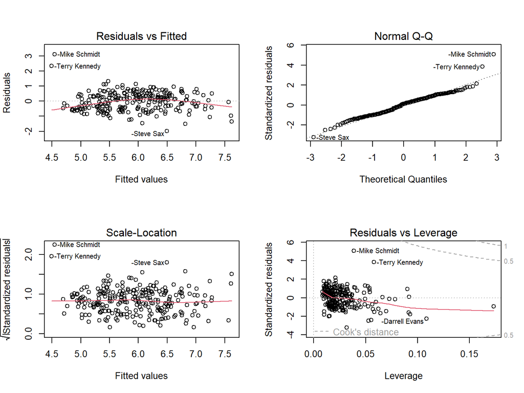

```r
par(mfrow = c(2,2))
plot(modeln)
```

분석결과  
Residuals vs Fitted : 잔차의 평균이 0에 가까운 점에서 분포하고 상관관계가 뚜렷하게 나타나지 않고 있음 선형성 만족  
Normal Q-Q : 잔차의 대부분이 45도 각도 위에 존재하여 정규성을 만족한다 볼 수 있지만 몇가지 이상수치가 존재  
Scale-Location :기울기가 0인 수평선 주위에 값이 고르게 존재하는 것으로 보아 등분산성을 만족한다고 볼 수 있음  
Residuals vs Leverage : 독립변수가 극단적으로 치우쳐 있지는 않은 지 확인  
Cook’s distance 값이 0에 가깝고 이상치가 다수 존재하지는 않아 큰 문제가 없어 보임

## 1.4 선형회귀 결과해석

```r
summary(modeln)
```

```
##
## Call:
## lm(formula = log(Salary) ~ Hits + Walks + Years + CWalks + Division +
##     PutOuts, data = Hitters)
##
## Residuals:
##      Min       1Q   Median       3Q      Max
## -1.99409 -0.46706  0.06891  0.40514  3.11440
##
## Coefficients:
##               Estimate Std. Error t value Pr(>|t|)
## (Intercept)  4.3381805  0.1391280  31.181  < 2e-16 ***
## Hits         0.0063952  0.0011057   5.784 2.12e-08 ***
## Walks        0.0051712  0.0027754   1.863   0.0636 .
## Years        0.0895907  0.0167900   5.336 2.09e-07 ***
## CWalks       0.0001256  0.0003388   0.371   0.7111
## DivisionW   -0.1770721  0.0774673  -2.286   0.0231 *
## PutOuts      0.0003072  0.0001461   2.102   0.0365 *
## ---
## Signif. codes:  0 '***' 0.001 '**' 0.01 '*' 0.05 '.' 0.1 ' ' 1
##
## Residual standard error: 0.6251 on 256 degrees of freedom
## Multiple R-squared:  0.5171, Adjusted R-squared:  0.5058
## F-statistic:  45.7 on 6 and 256 DF,  p-value: < 2.2e-16
```

p-value 값에 의해 CWalks 변수를 제거

```r
modeln = lm(log(Salary) ~ Hits + Walks + Years + Division + PutOuts  , data = Hitters)
summary(modeln)
```

```
##
## Call:
## lm(formula = log(Salary) ~ Hits + Walks + Years + Division +
##     PutOuts, data = Hitters)
##
## Residuals:
##      Min       1Q   Median       3Q      Max
## -1.98610 -0.46300  0.06483  0.41328  3.12556
##
## Coefficients:
##               Estimate Std. Error t value Pr(>|t|)
## (Intercept)  4.3167391  0.1263269  34.171  < 2e-16 ***
## Hits         0.0063030  0.0010756   5.860 1.41e-08 ***
## Walks        0.0057753  0.0022429   2.575   0.0106 *
## Years        0.0950303  0.0081503  11.660  < 2e-16 ***
## DivisionW   -0.1781438  0.0772834  -2.305   0.0220 *
## PutOuts      0.0003072  0.0001459   2.106   0.0362 *
## ---
## Signif. codes:  0 '***' 0.001 '**' 0.01 '*' 0.05 '.' 0.1 ' ' 1
##
## Residual standard error: 0.624 on 257 degrees of freedom
## Multiple R-squared:  0.5169, Adjusted R-squared:  0.5075
## F-statistic: 54.99 on 5 and 257 DF,  p-value: < 2.2e-16
```

모델의 예측정도를 평가하고자 지표를 측정  
RMSE, MAPE값 등을 평가 지표로 활용

```r
library(forecast)
accuracy(modeln)
```

```
##                       ME      RMSE       MAE       MPE     MAPE      MASE
## Training set 1.01142e-17 0.6168736 0.4940088 -1.164813 8.613902 0.6556204
```

# 2 로지스틱 회귀분석 과제

회귀분석에서 사용한 타자 데이터로 진행하려했으나 로지스틱 회귀분석에 어려움이 있을거라 생각해  
다른 야구데이터인 1962 ~ 2012년 MLB 팀 성과 데이터를 이용했다.  
이를 통해 플레이오프에 진출 여부를 종속변수로 한 로지스틱 회귀분석 모형을 만들어 보고자 한다.

## 2.1 데이터 수집

```r
BB <- read.csv("C:/Users/KUPISEDU1/Documents/baseball.csv")
summary(BB)
```

```
##      Team              League               Year            RS
##  Length:1232        Length:1232        Min.   :1962   Min.   : 463.0
##  Class :character   Class :character   1st Qu.:1977   1st Qu.: 652.0
##  Mode  :character   Mode  :character   Median :1989   Median : 711.0
##                                        Mean   :1989   Mean   : 715.1
##                                        3rd Qu.:2002   3rd Qu.: 775.0
##                                        Max.   :2012   Max.   :1009.0
##
##        RA               W              OBP              SLG
##  Min.   : 472.0   Min.   : 40.0   Min.   :0.2770   Min.   :0.3010
##  1st Qu.: 649.8   1st Qu.: 73.0   1st Qu.:0.3170   1st Qu.:0.3750
##  Median : 709.0   Median : 81.0   Median :0.3260   Median :0.3960
##  Mean   : 715.1   Mean   : 80.9   Mean   :0.3263   Mean   :0.3973
##  3rd Qu.: 774.2   3rd Qu.: 89.0   3rd Qu.:0.3370   3rd Qu.:0.4210
##  Max.   :1103.0   Max.   :116.0   Max.   :0.3730   Max.   :0.4910
##
##        BA            Playoffs        RankSeason     RankPlayoffs
##  Min.   :0.2140   Min.   :0.0000   Min.   :1.000   Min.   :1.000
##  1st Qu.:0.2510   1st Qu.:0.0000   1st Qu.:2.000   1st Qu.:2.000
##  Median :0.2600   Median :0.0000   Median :3.000   Median :3.000
##  Mean   :0.2593   Mean   :0.1981   Mean   :3.123   Mean   :2.717
##  3rd Qu.:0.2680   3rd Qu.:0.0000   3rd Qu.:4.000   3rd Qu.:4.000
##  Max.   :0.2940   Max.   :1.0000   Max.   :8.000   Max.   :5.000
##                                    NA's   :988     NA's   :988
##        G              OOBP             OSLG
##  Min.   :158.0   Min.   :0.2940   Min.   :0.3460
##  1st Qu.:162.0   1st Qu.:0.3210   1st Qu.:0.4010
##  Median :162.0   Median :0.3310   Median :0.4190
##  Mean   :161.9   Mean   :0.3323   Mean   :0.4197
##  3rd Qu.:162.0   3rd Qu.:0.3430   3rd Qu.:0.4380
##  Max.   :165.0   Max.   :0.3840   Max.   :0.4990
##                  NA's   :812      NA's   :812
```

변수 설명

RS- Runs Scored  
RA- Runs Allowed  
W-Number of regular season wins  
OBP - On base percentage of the team  
slg-Slugging Percentage  
BA - Batting Average of the team  
Playoffs - whether the team made it to playoffs(0 or 1)  
RankSeason- Ranking of their regular season records among playoff teams RankPlayoffs - Rank based on team’s performance in playoffs,  
G- Number of games played  
OOBP- Opponents on base percentage  
OSLG- Opponents slugging percentage

### 2.1.1 데이터 전처리 1

플레이오프 진출 여부를 판단하는 것이기에  
Rankseason, RankPlayoffs 변수는 필요하지 않음  
따라서 해당 변수는 데이터 프레임에서 제거

```r
#subset함수를 사용
bb <- subset(BB, select=-RankSeason)
bb <- subset(bb, select=-RankPlayoffs)
```

잘 제거 되었는지 확인

```r
head(bb)
```

```
##   Team League Year  RS  RA  W   OBP   SLG    BA Playoffs   G  OOBP  OSLG
## 1  ARI     NL 2012 734 688 81 0.328 0.418 0.259        0 162 0.317 0.415
## 2  ATL     NL 2012 700 600 94 0.320 0.389 0.247        1 162 0.306 0.378
## 3  BAL     AL 2012 712 705 93 0.311 0.417 0.247        1 162 0.315 0.403
## 4  BOS     AL 2012 734 806 69 0.315 0.415 0.260        0 162 0.331 0.428
## 5  CHC     NL 2012 613 759 61 0.302 0.378 0.240        0 162 0.335 0.424
## 6  CHW     AL 2012 748 676 85 0.318 0.422 0.255        0 162 0.319 0.405
```

Team 변수 또한 분석에 유의미하지 않은 데이터 값이기에 제거

```r
bb <- bb[,-c(1)]
str(bb)
```

```
## 'data.frame':    1232 obs. of  12 variables:
##  $ League  : chr  "NL" "NL" "AL" "AL" ...
##  $ Year    : int  2012 2012 2012 2012 2012 2012 2012 2012 2012 2012 ...
##  $ RS      : int  734 700 712 734 613 748 669 667 758 726 ...
##  $ RA      : int  688 600 705 806 759 676 588 845 890 670 ...
##  $ W       : int  81 94 93 69 61 85 97 68 64 88 ...
##  $ OBP     : num  0.328 0.32 0.311 0.315 0.302 0.318 0.315 0.324 0.33 0.335 ...
##  $ SLG     : num  0.418 0.389 0.417 0.415 0.378 0.422 0.411 0.381 0.436 0.422 ...
##  $ BA      : num  0.259 0.247 0.247 0.26 0.24 0.255 0.251 0.251 0.274 0.268 ...
##  $ Playoffs: int  0 1 1 0 0 0 1 0 0 1 ...
##  $ G       : int  162 162 162 162 162 162 162 162 162 162 ...
##  $ OOBP    : num  0.317 0.306 0.315 0.331 0.335 0.319 0.305 0.336 0.357 0.314 ...
##  $ OSLG    : num  0.415 0.378 0.403 0.428 0.424 0.405 0.39 0.43 0.47 0.402 ...
```

### 2.1.2 데이터 전처리 2

데이터의 결측치가 있는지 확인

```r
sum(is.na(bb))
```

```
## [1] 1624
```

변수 OOBP, OSLG의 결측치들을 평균 값으로 대치

```r
bb$OOBP <- ifelse(is.na(bb$OOBP), mean(bb$OOBP, na.rm = T), bb$OOBP)
bb$OSLG <- ifelse(is.na(bb$OSLG), mean(bb$OSLG, na.rm = T), bb$OSLG)
```

결측치가 사라졌는지 확인

```r
sum(is.na(bb))
```

```
## [1] 0
```

### 2.1.3 데이터 전처리 3

범주형 데이터인 League 값을 더미 변수로 변환

```r
library(dummies)
bb <- dummy.data.frame(bb, names=c("League"))
#확인
head(bb)
```

```
##   LeagueAL LeagueNL Year  RS  RA  W   OBP   SLG    BA Playoffs   G  OOBP  OSLG
## 1        0        1 2012 734 688 81 0.328 0.418 0.259        0 162 0.317 0.415
## 2        0        1 2012 700 600 94 0.320 0.389 0.247        1 162 0.306 0.378
## 3        1        0 2012 712 705 93 0.311 0.417 0.247        1 162 0.315 0.403
## 4        1        0 2012 734 806 69 0.315 0.415 0.260        0 162 0.331 0.428
## 5        0        1 2012 613 759 61 0.302 0.378 0.240        0 162 0.335 0.424
## 6        1        0 2012 748 676 85 0.318 0.422 0.255        0 162 0.319 0.405
```

## 2.2 탐색적 데이터 분석

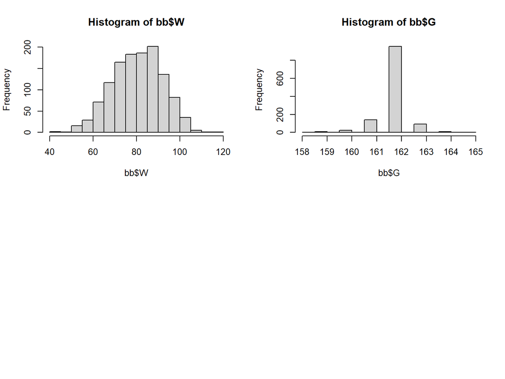

```r
library("ggplot2")
par(mfrow=c(2,2))
hist(bb$W)
hist(bb$G)


par(mfrow=c(2,2))
```

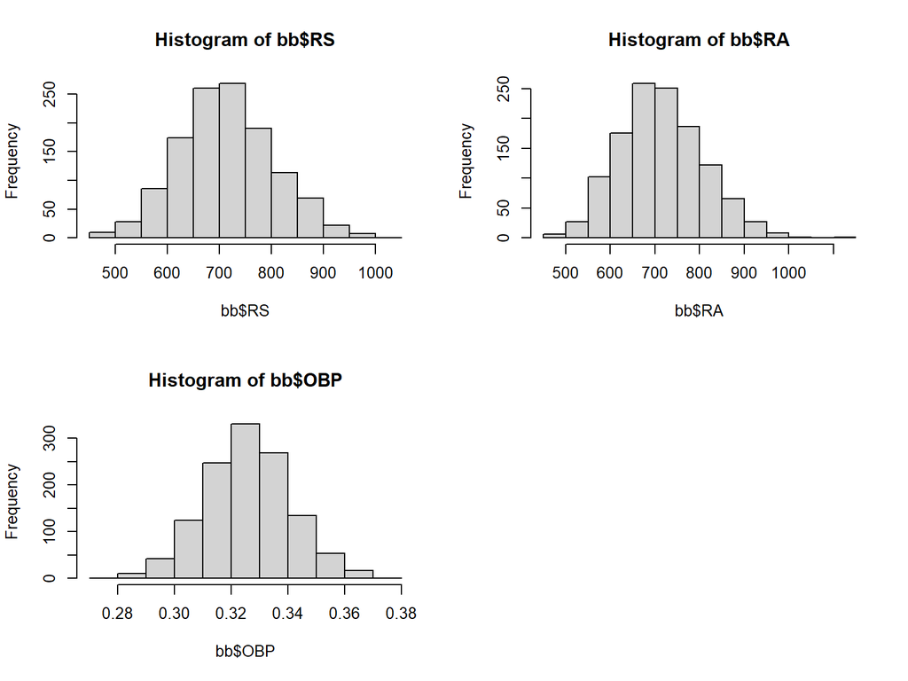

```r
hist(bb$RS)
hist(bb$RA)
hist(bb$OBP)


par(mfrow=c(2,2))
```

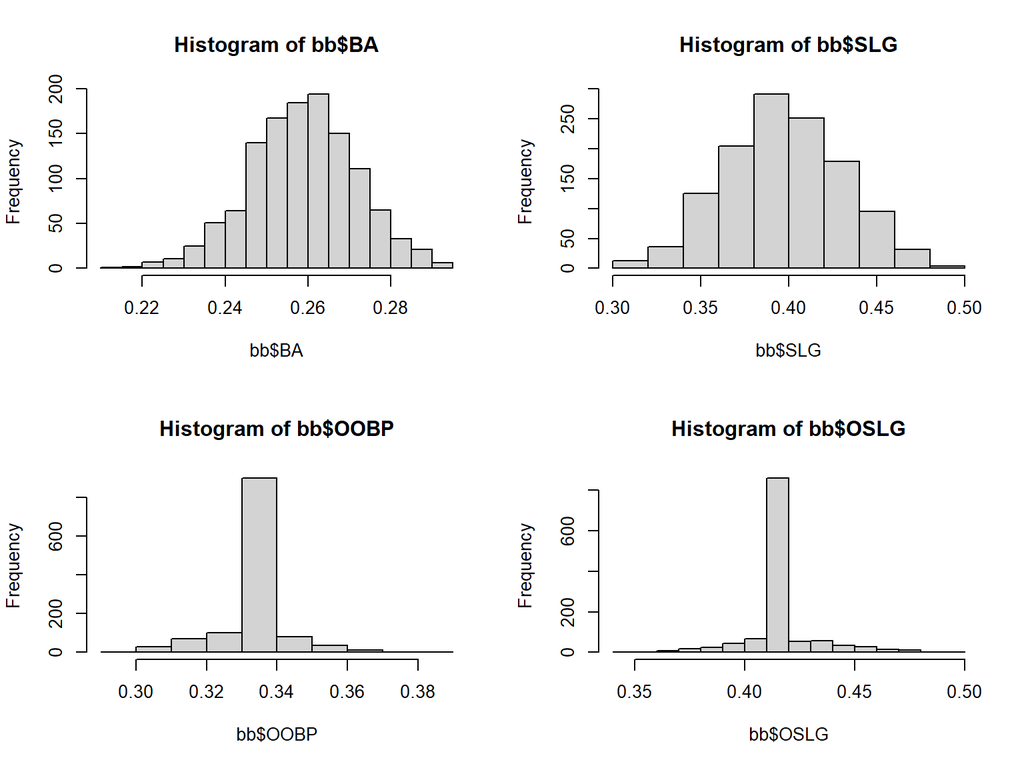

```r
hist(bb$BA)
hist(bb$SLG)
hist(bb$OOBP)
hist(bb$OSLG)
```

히스토그램을 통해 여러 지표들의 특징을 확인  
OOBP, OSLG는 평균값 대체 빈도로 인해 위와 같은 양상을 보임  
G는 1962년 162경기로 변경 후 지금까지 유지되고 있어 위와 같은 양상을 보임  
나머지 변수들에 특이점은 발견되지 않음

모델 구축 준비 완료

## 2.3 모형 구축

모형 구축에 앞서 먼저 데이터를 학습/테스트로 구분

### 2.3.1 데이터 구분

```r
#데이터를 학습데이터와 테스트 데이터로 구분

te=subset(bb,bb$Year %in% c('2010','2011','2012'))
tr=subset(bb,as.numeric(bb$Year)<2010)
```

데이터를 나누는 기준은 여러가지가 있지만 최근 데이터를 검증 데이터로 하고자 2010년을 기준으로 구분

```r
summary(tr)
```

```
##     LeagueAL         LeagueNL           Year            RS
##  Min.   :0.0000   Min.   :0.0000   Min.   :1962   Min.   : 463.0
##  1st Qu.:0.0000   1st Qu.:0.0000   1st Qu.:1976   1st Qu.: 652.2
##  Median :1.0000   Median :0.0000   Median :1988   Median : 711.0
##  Mean   :0.5026   Mean   :0.4974   Mean   :1987   Mean   : 716.2
##  3rd Qu.:1.0000   3rd Qu.:1.0000   3rd Qu.:2000   3rd Qu.: 777.0
##  Max.   :1.0000   Max.   :1.0000   Max.   :2009   Max.   :1009.0
##        RA               W              OBP              SLG
##  Min.   : 472.0   Min.   : 40.0   Min.   :0.2770   Min.   :0.301
##  1st Qu.: 650.0   1st Qu.: 73.0   1st Qu.:0.3170   1st Qu.:0.374
##  Median : 711.0   Median : 81.0   Median :0.3260   Median :0.396
##  Mean   : 716.2   Mean   : 80.9   Mean   :0.3267   Mean   :0.397
##  3rd Qu.: 777.8   3rd Qu.: 89.0   3rd Qu.:0.3370   3rd Qu.:0.421
##  Max.   :1103.0   Max.   :116.0   Max.   :0.3730   Max.   :0.491
##        BA            Playoffs            G              OOBP
##  Min.   :0.2140   Min.   :0.0000   Min.   :158.0   Min.   :0.3010
##  1st Qu.:0.2510   1st Qu.:0.0000   1st Qu.:162.0   1st Qu.:0.3323
##  Median :0.2600   Median :0.0000   Median :162.0   Median :0.3323
##  Mean   :0.2596   Mean   :0.1909   Mean   :161.9   Mean   :0.3331
##  3rd Qu.:0.2680   3rd Qu.:0.0000   3rd Qu.:162.0   3rd Qu.:0.3323
##  Max.   :0.2940   Max.   :1.0000   Max.   :165.0   Max.   :0.3840
##       OSLG
##  Min.   :0.3540
##  1st Qu.:0.4197
##  Median :0.4197
##  Mean   :0.4211
##  3rd Qu.:0.4197
##  Max.   :0.4990
```

잘 구분 되었는지 확인

```r
summary(te)
```

```
##     LeagueAL         LeagueNL           Year            RS
##  Min.   :0.0000   Min.   :0.0000   Min.   :2010   Min.   :513.0
##  1st Qu.:0.0000   1st Qu.:0.0000   1st Qu.:2010   1st Qu.:651.0
##  Median :0.0000   Median :1.0000   Median :2011   Median :707.5
##  Mean   :0.4667   Mean   :0.5333   Mean   :2011   Mean   :701.5
##  3rd Qu.:1.0000   3rd Qu.:1.0000   3rd Qu.:2012   3rd Qu.:749.5
##  Max.   :1.0000   Max.   :1.0000   Max.   :2012   Max.   :875.0
##        RA              W               OBP              SLG
##  Min.   :529.0   Min.   : 55.00   Min.   :0.2920   Min.   :0.3390
##  1st Qu.:649.0   1st Qu.: 72.00   1st Qu.:0.3132   1st Qu.:0.3830
##  Median :700.5   Median : 81.00   Median :0.3210   Median :0.4015
##  Mean   :701.5   Mean   : 80.99   Mean   :0.3216   Mean   :0.4022
##  3rd Qu.:745.5   3rd Qu.: 90.00   3rd Qu.:0.3320   3rd Qu.:0.4198
##  Max.   :890.0   Max.   :102.00   Max.   :0.3500   Max.   :0.4610
##        BA            Playoffs            G            OOBP
##  Min.   :0.2330   Min.   :0.0000   Min.   :161   Min.   :0.2940
##  1st Qu.:0.2470   1st Qu.:0.0000   1st Qu.:162   1st Qu.:0.3130
##  Median :0.2550   Median :0.0000   Median :162   Median :0.3190
##  Mean   :0.2555   Mean   :0.2889   Mean   :162   Mean   :0.3215
##  3rd Qu.:0.2630   3rd Qu.:1.0000   3rd Qu.:162   3rd Qu.:0.3310
##  Max.   :0.2830   Max.   :1.0000   Max.   :162   Max.   :0.3570
##       OSLG
##  Min.   :0.3460
##  1st Qu.:0.3885
##  Median :0.4005
##  Mean   :0.4022
##  3rd Qu.:0.4150
##  Max.   :0.4700
```

### 2.3.2 모형 구축

```r
model1 <- glm(Playoffs~ ., tr, family = binomial())
summary(model1)
```

```
##
## Call:
## glm(formula = Playoffs ~ ., family = binomial(), data = tr)
##
## Deviance Residuals:
##      Min        1Q    Median        3Q       Max
## -3.15046  -0.22727  -0.04551  -0.00327   2.95071
##
## Coefficients: (1 not defined because of singularities)
##               Estimate Std. Error z value Pr(>|z|)
## (Intercept) -1.234e+02  4.660e+01  -2.649  0.00808 **
## LeagueAL    -4.926e-01  2.762e-01  -1.784  0.07450 .
## LeagueNL            NA         NA      NA       NA
## Year         6.641e-02  1.409e-02   4.714 2.43e-06 ***
## RS           5.123e-03  6.208e-03   0.825  0.40925
## RA          -2.210e-03  4.207e-03  -0.525  0.59940
## W            3.819e-01  4.151e-02   9.202  < 2e-16 ***
## OBP          1.488e+01  2.264e+01   0.657  0.51093
## SLG         -9.842e+00  1.163e+01  -0.846  0.39741
## BA          -5.609e+00  2.043e+01  -0.275  0.78363
## G           -2.995e-01  2.106e-01  -1.422  0.15495
## OOBP         1.190e+01  2.837e+01   0.419  0.67492
## OSLG        -1.875e+00  1.504e+01  -0.125  0.90074
## ---
## Signif. codes:  0 '***' 0.001 '**' 0.01 '*' 0.05 '.' 0.1 ' ' 1
##
## (Dispersion parameter for binomial family taken to be 1)
##
##     Null deviance: 1113.49  on 1141  degrees of freedom
## Residual deviance:  416.98  on 1130  degrees of freedom
## AIC: 440.98
##
## Number of Fisher Scoring iterations: 8
```

회귀분석에서 더미변수로 인한 결측값이 존재해  
변수를 삭제후 모델 재구축

### 2.3.3 데이터 전처리 4

```r
tr <- tr[,-c(1,2)]
te <- te[,-c(1,2)]
str(tr)
```

```
## 'data.frame':    1142 obs. of  11 variables:
##  $ Year    : int  2009 2009 2009 2009 2009 2009 2009 2009 2009 2009 ...
##  $ RS      : int  720 735 741 872 707 724 673 773 804 743 ...
##  $ RA      : int  782 641 876 736 672 732 723 865 715 745 ...
##  $ W       : int  70 86 64 95 83 79 78 65 92 86 ...
##  $ OBP     : num  0.324 0.339 0.332 0.352 0.332 0.329 0.318 0.339 0.343 0.331 ...
##  $ SLG     : num  0.418 0.405 0.415 0.454 0.407 0.411 0.394 0.417 0.441 0.416 ...
##  $ BA      : num  0.253 0.263 0.268 0.27 0.255 0.258 0.247 0.264 0.261 0.26 ...
##  $ Playoffs: int  0 0 0 1 0 0 0 0 1 0 ...
##  $ G       : int  162 162 162 162 161 162 162 162 162 163 ...
##  $ OOBP    : num  0.33 0.323 0.353 0.335 0.324 0.325 0.333 0.351 0.328 0.336 ...
##  $ OSLG    : num  0.419 0.39 0.476 0.422 0.391 0.414 0.418 0.443 0.405 0.422 ...
```

```r
str(te)
```

```
## 'data.frame':    90 obs. of  11 variables:
##  $ Year    : int  2012 2012 2012 2012 2012 2012 2012 2012 2012 2012 ...
##  $ RS      : int  734 700 712 734 613 748 669 667 758 726 ...
##  $ RA      : int  688 600 705 806 759 676 588 845 890 670 ...
##  $ W       : int  81 94 93 69 61 85 97 68 64 88 ...
##  $ OBP     : num  0.328 0.32 0.311 0.315 0.302 0.318 0.315 0.324 0.33 0.335 ...
##  $ SLG     : num  0.418 0.389 0.417 0.415 0.378 0.422 0.411 0.381 0.436 0.422 ...
##  $ BA      : num  0.259 0.247 0.247 0.26 0.24 0.255 0.251 0.251 0.274 0.268 ...
##  $ Playoffs: int  0 1 1 0 0 0 1 0 0 1 ...
##  $ G       : int  162 162 162 162 162 162 162 162 162 162 ...
##  $ OOBP    : num  0.317 0.306 0.315 0.331 0.335 0.319 0.305 0.336 0.357 0.314 ...
##  $ OSLG    : num  0.415 0.378 0.403 0.428 0.424 0.405 0.39 0.43 0.47 0.402 ...
```

모델 재구축

```r
model1 <- glm(Playoffs~ ., tr, family = binomial())
summary(model1)
```

```
##
## Call:
## glm(formula = Playoffs ~ ., family = binomial(), data = tr)
##
## Deviance Residuals:
##      Min        1Q    Median        3Q       Max
## -3.05937  -0.24132  -0.04738  -0.00377   2.99901
##
## Coefficients:
##               Estimate Std. Error z value Pr(>|z|)
## (Intercept) -1.391e+02  4.586e+01  -3.033  0.00242 **
## Year         7.092e-02  1.394e-02   5.088 3.62e-07 ***
## RS           3.903e-03  6.097e-03   0.640  0.52211
## RA          -2.523e-03  4.215e-03  -0.598  0.54953
## W            3.805e-01  4.144e-02   9.182  < 2e-16 ***
## OBP          1.476e+01  2.245e+01   0.658  0.51076
## SLG         -9.141e+00  1.148e+01  -0.796  0.42588
## BA          -7.017e+00  2.030e+01  -0.346  0.72957
## G           -2.567e-01  2.075e-01  -1.237  0.21602
## OOBP         1.533e+01  2.838e+01   0.540  0.58919
## OSLG        -2.414e+00  1.519e+01  -0.159  0.87372
## ---
## Signif. codes:  0 '***' 0.001 '**' 0.01 '*' 0.05 '.' 0.1 ' ' 1
##
## (Dispersion parameter for binomial family taken to be 1)
##
##     Null deviance: 1113.49  on 1141  degrees of freedom
## Residual deviance:  420.21  on 1131  degrees of freedom
## AIC: 442.21
##
## Number of Fisher Scoring iterations: 8
```

## 2.4 로지스틱 회귀 결과 해석

```r
pred_prob <- predict(model1, te, type="response")
pred_class <- rep(0, nrow(te))
pred_class[pred_prob > 0.5] <- 1
cm <- table(pred=pred_class, actual=te$Playoffs)
```

모형의 결과를 해석하기위해 함수 설정

```r
perf_eval <- function(cm){
  # true positive rate
  TPR = Recall = cm[2,2]/sum(cm[2,])
  # precision
  Precision = cm[2,2]/sum(cm[,2])
  # true negative rate
  TNR = cm[1,1]/sum(cm[1,])
  # accuracy
  ACC = sum(diag(cm)) / sum(cm)
  # balance corrected accuracy (geometric mean)
  BCR = sqrt(TPR*TNR)
  # f1 measure
  F1 = 2 * Recall * Precision / (Recall + Precision)

  re <- data.frame(TPR = TPR,
                   Precision = Precision,
                   TNR = TNR,
                   ACC = ACC,
                   BCR = BCR,
                   F1 = F1)
  return(re)
}
```

perf_eval 함수 실행

```r
perf_eval(cm)
```

```
##         TPR Precision       TNR       ACC       BCR        F1
## 1 0.8571429 0.9230769 0.9677419 0.9333333 0.9107651 0.8888889
```

## 2.5 변수선택법 적용

3가지 변수 선택법을 모두 적용

### 2.5.1 변수 선택 1

```r
#forward selection
model_fwd <- step(glm(Playoffs ~ 1, tr,
                      family = binomial()),
                  direction = "forward", trace = 0,
                  scope = formula(model1))

pred_prob <- predict(model_fwd, te, type="response")
pred_class <- rep(0, nrow(te))
pred_class[pred_prob > 0.5] <- 1
cm <- table(pred=pred_class, actual=te$Playoffs)

perf_eval(cm)
```

```
##   TPR Precision       TNR       ACC       BCR        F1
## 1 0.8 0.9230769 0.9666667 0.9111111 0.8793937 0.8571429
```

### 2.5.2 변수 선택 2

```r
#backward elimination
model_bwd <- step(glm(Playoffs ~ ., tr,
                      family = binomial()),
                  direction = "backward", trace = 0,
                  scope = list(lower=Playoffs ~ 1, upper = formula(model1)))

pred_prob <- predict(model_bwd, te, type="response")
pred_class <- rep(0, nrow(te))
pred_class[pred_prob > 0.5] <- 1
cm <- table(pred=pred_class, actual=te$Playoffs)

perf_eval(cm)
```

```
##   TPR Precision       TNR       ACC       BCR        F1
## 1 0.8 0.9230769 0.9666667 0.9111111 0.8793937 0.8571429
```

### 2.5.3 변수 선택 3

```r
#stepwise selection
model_step <- step(glm(Playoffs ~ ., tr,
                       family = binomial()), direction = "both", trace = 0,
                  scope = list(lower=Playoffs ~ 1, upper = formula(model1)))

pred_prob <- predict(model_step, te, type="response")
pred_class <- rep(0, nrow(te))
pred_class[pred_prob > 0.5] <- 1
cm <- table(pred=pred_class, actual=te$Playoffs)

perf_eval(cm)
```

```
##   TPR Precision       TNR       ACC       BCR        F1
## 1 0.8 0.9230769 0.9666667 0.9111111 0.8793937 0.8571429
```

3가지 변수 선택법으로 인해 구축한 모델이 모두 같은 형태를 띄고 있음 정확도와 F1값이 높은 것으로 보아 성능이 괜찮은 모델이라는 것을 알 수 있음

## 2.6 review

정보융합학부에서 진행하는 첫 실습이라 걱정과 두려움이 앞섰다.  
과제라 정답방향을 교수님께 질의할수도, 그렇다고 타과라 물어볼 지인도 없었기에  
남들보다 더 많은 시간을 투자했던 것 같다.  
하지만 그래서 더 값진 시간이었다.  
이미 졸업할 시기가 지났기에 많은 것을 얻어가야하는 올해 1학기의 시작이 데이터마이닝 실습과 함께라 더 특별했다.  
기계학습도 파이팅!

2022.05.02